# ggplot2

## Another perspective with dotplots (Vertical bins)

> What if we want to compare the distribution of Infection (No vs Yes) side by side ? We will need to map the infection variable to the x axis and move the age variable to the y axis. We’ll also keep the infection variable with the `fill` argument that way a separate color will be used for infection = No and infection = Yes

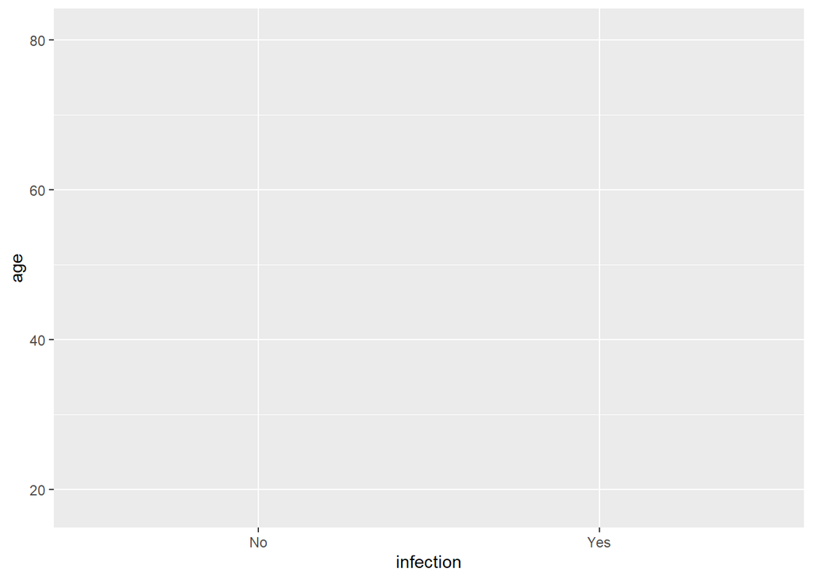

```r
ggplot(df, aes(y = age, x = infection, fill = infection))
```

> Now we have the basis of the plot, we can add the dotplot geom once again, except we’ll bin the histodots on the y axis instead of x and keep the stack aligned to the center. We can do this using the `binaxis` argument specifying it on the y axis and we want the stacks within the center

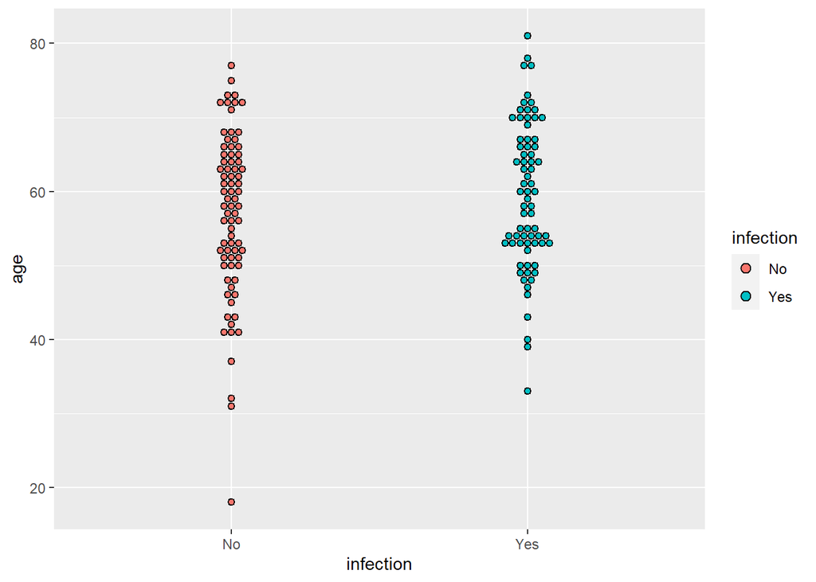

```r
ggplot(df, aes(y = age, x = infection, fill = infection)) +
  geom_dotplot(binaxis = "y", stackdir = "center",
               binwidth = 1, method = "histodot")
```

> Now let’s add some descriptive indicators on the plot via the `stat_summary()` function. Let’s add an indicator of the medians for both the non infection group and the infection group. `stat_summary()` allows us to map a function to the y axis. We will use the `median` function to accomplish this, and use the geom crossbar to visualize the measure.

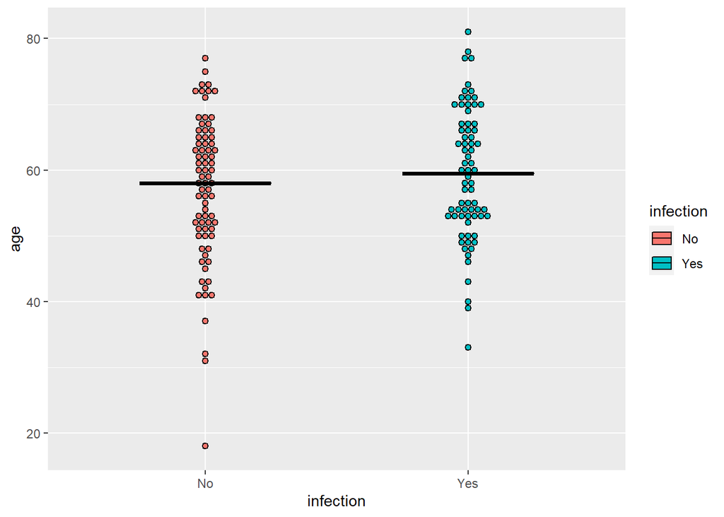

```r
ggplot(df, aes(y = age, x = infection, fill = infection)) +
  geom_dotplot(binaxis = "y", stackdir = "center",
               binwidth = 1, method = "histodot") +
  stat_summary(fun.y = median, fun.ymin = median, fun.ymax = median, geom = "crossbar", width = 0.5)
```

> Let’s finish cleaning up the plot with some of the other functions we have learned

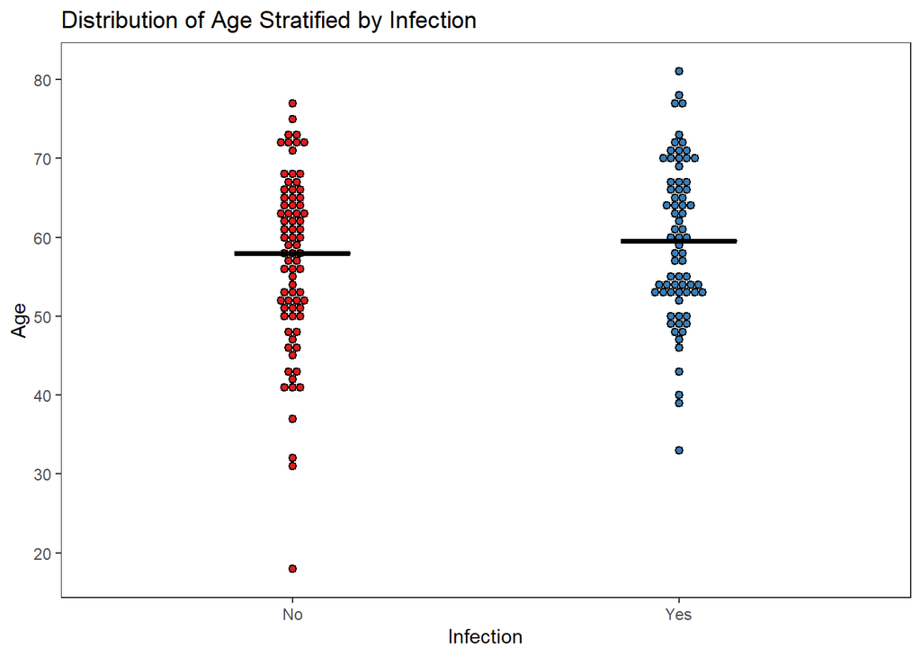

```r
# manually calculate the median age by infection group

ggplot(df, aes(y = age, x = infection, fill = infection)) +
  geom_dotplot(binaxis = "y", stackdir = "center",
               binwidth = 1, method = "histodot") +
  stat_summary(fun.y = median, fun.ymin = median, fun.ymax = median, geom = "crossbar", width = 0.3) +
  theme_bw() +
  theme(legend.position = "none",
        panel.grid = element_blank()) +
  scale_fill_brewer("infection", palette = "Set1") +
  labs(y = "Age", x = "Infection", title = 'Distribution of Age Stratified by Infection') +
  scale_y_continuous(breaks = seq(0,100, 10))
```

[output not shown]

# Saving the plot we just made

> Now that we’re happy with the plot we just made, we should save it so we can share it with our collaborators. There are we can do this by invoking the `ggsave()` function. By default `ggsave()` will save the last plot that was rendered, however we can also specify the plot we would like to save as well.

> The command for `ggsave()` is `ggsave(filename = NULL, plot = last_plot(), ...)`. Please see the documentation for further details using `?ggsave`, for other possible arguments to configure.

```r
ggsave('my_first_plot.png', height = 6, width = 8)
```

> This function will save the previous plot, in your project directory as my_first_plot.png, with a height of 6 inches, and a width of 8 inches.

# Histogram plots

> We start off with the same base template of ggplot2, by assigning ggplot2 the 2 initial requirements for a plot. The name of the dataframe and a mapping for the coordinate within the aesthetic.

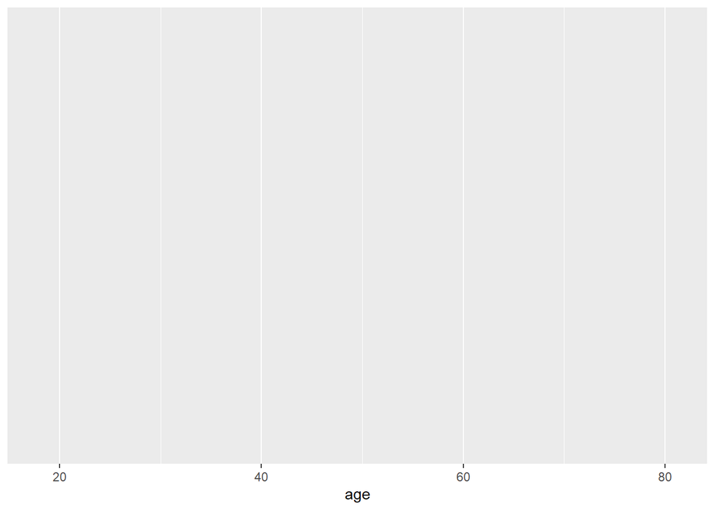

```r
ggplot(df, aes(x = age))
```

> Next we move forward with stating the name of the geom we want to use, let’s try out the histogram geom called `geom_histogram()`. This is the basic foundation for all plots with ggplot2. The initial function `ggplot()` with the addition of visualization geoms we add layer by layer. Please feel free to experiment with additional geoms, however we will probably not have time to go through all of them.

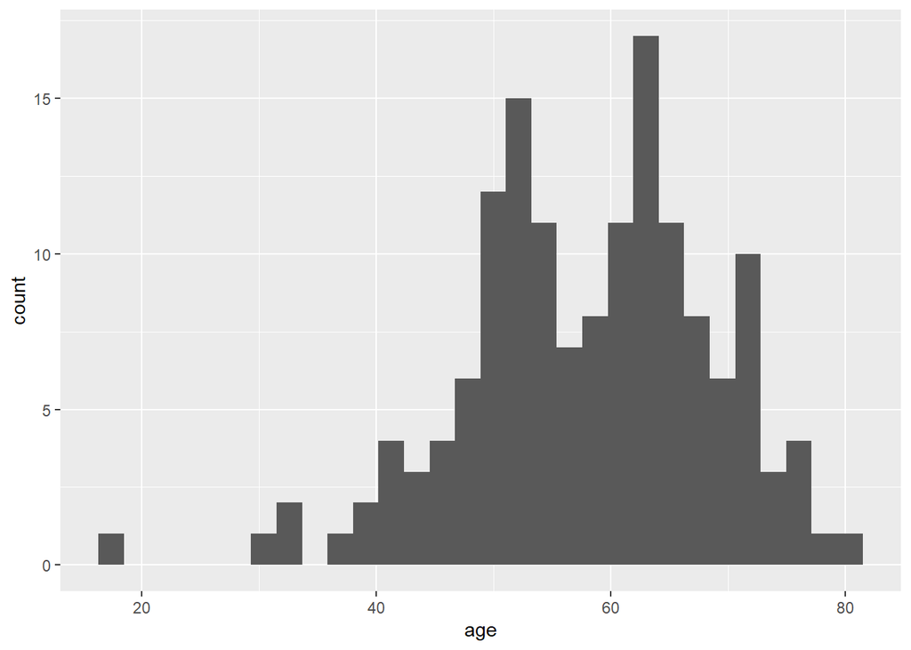

```r
ggplot(df, aes(x = age)) + geom_histogram()
```

> Huzzah! We have a histogram of age, a method of visualizing the distribution of age. Lets follow the same idea of the dotplot by changing the width of the columns of our histogram. `geom_histogram` also has the same argument called `binwidth` which allows us to make that change. `binwidth = 5` allows us to change the width of the bins (columns) to every 5 years of age. We can also better visualize this by changing the scale on the x axis with `scale_x_continuous()`

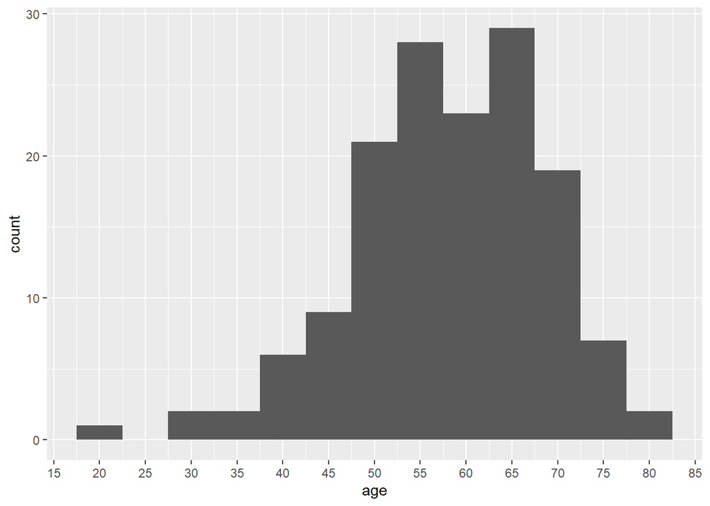

```r
ggplot(df, aes(x = age)) +
  geom_histogram(binwidth = 5) +
  scale_x_continuous(breaks = seq(0,100,5))
```

> Lets add a theme

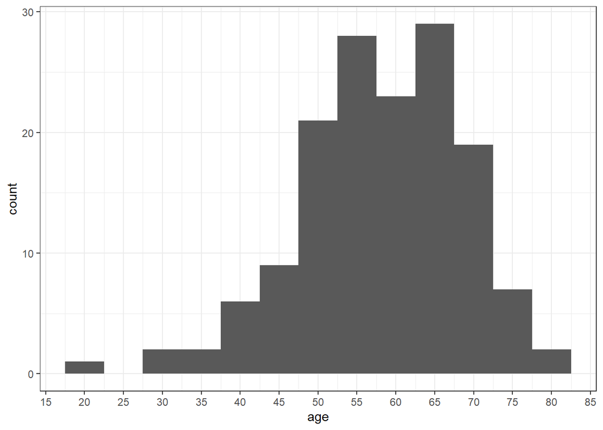

```r
ggplot(df, aes(x = age)) +
  geom_histogram(binwidth = 5) +
  scale_x_continuous(breaks = seq(0,100,5)) +
  theme_bw()
```

> The histogram also has the ability to show the density on the y axis instead of counts. We can do this by specifying the mapping within the `aes()` function by using `y = after_stat(density)`

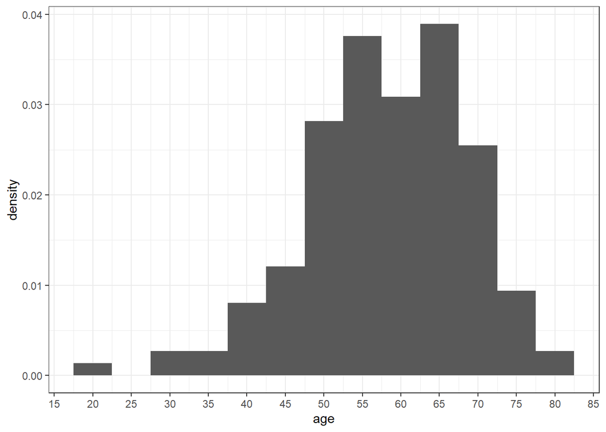

```r
ggplot(df, aes(x = age, y = after_stat(density))) +
  geom_histogram(binwidth = 5) +
  scale_x_continuous(breaks = seq(0,100,5)) +
  theme_bw()
```

> We can add colors by mapping the fill aesthetic with our variable infection. Of note, by default, adding a fill will produce a stacked histogram (e.g. the height of the bar is the total count of both infection no and infection yes stacked on top of each other)

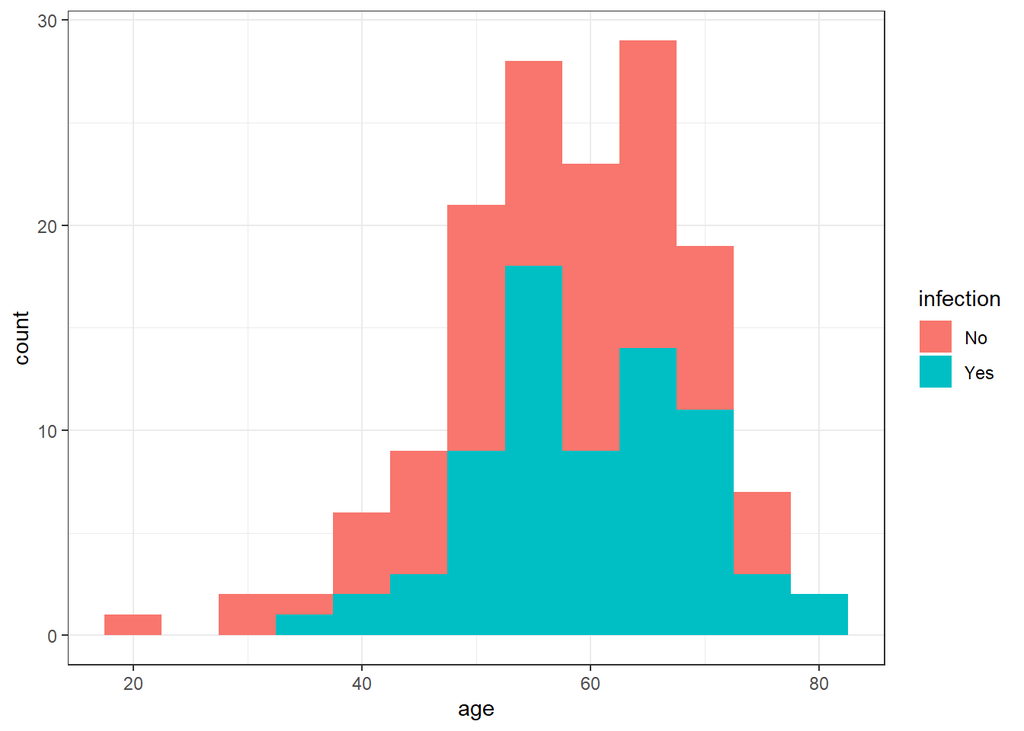

```r
ggplot(df, aes(x = age, fill = infection)) +
  geom_histogram(binwidth = 5) +
  theme_bw()
```

> Changing the axis and scale titles

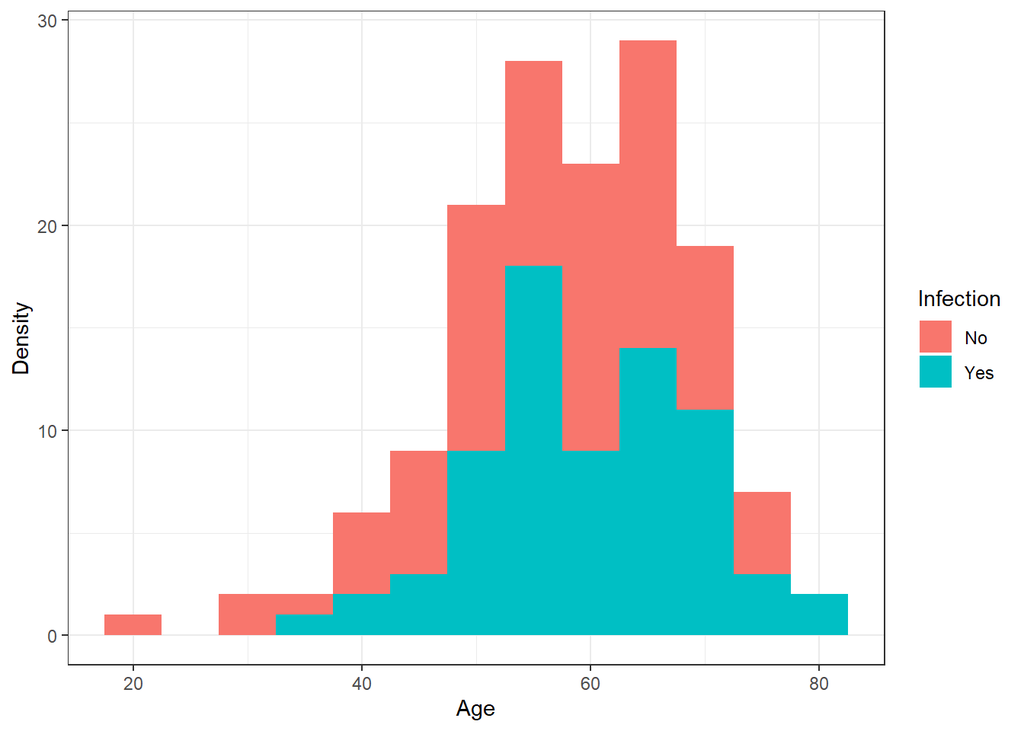

```r
ggplot(df, aes(x = age, fill = infection)) +
  geom_histogram(binwidth = 5)  +
  theme_bw() +
  scale_fill_discrete("Infection") +
  labs(x = "Age", y = "Density")
```

> Changing the colors by utilizing a palette

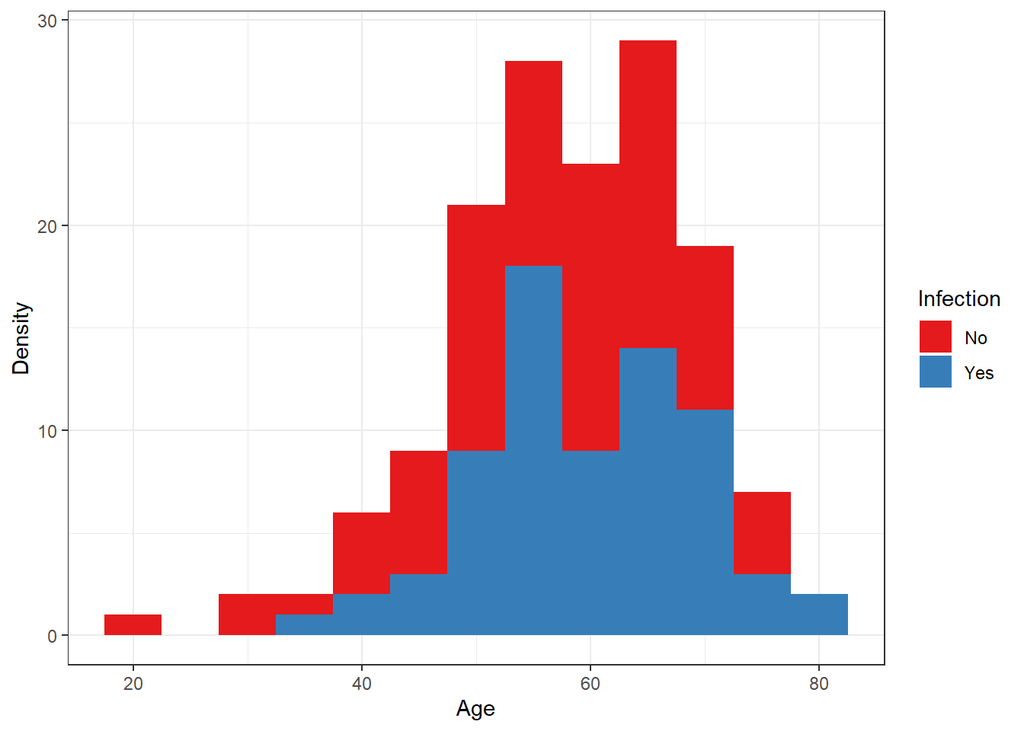

```r
ggplot(df, aes(x = age, fill = infection)) +
  geom_histogram(binwidth = 5)  +
  theme_bw() +
  scale_fill_brewer("Infection", palette = "Set1") +
  labs(x = "Age", y = "Density")
```

> Since stacked histograms are not very useful, and we are interested in visualizing the distriubtion of both infection No and Yes separately, we can use different panels or ‘facets’

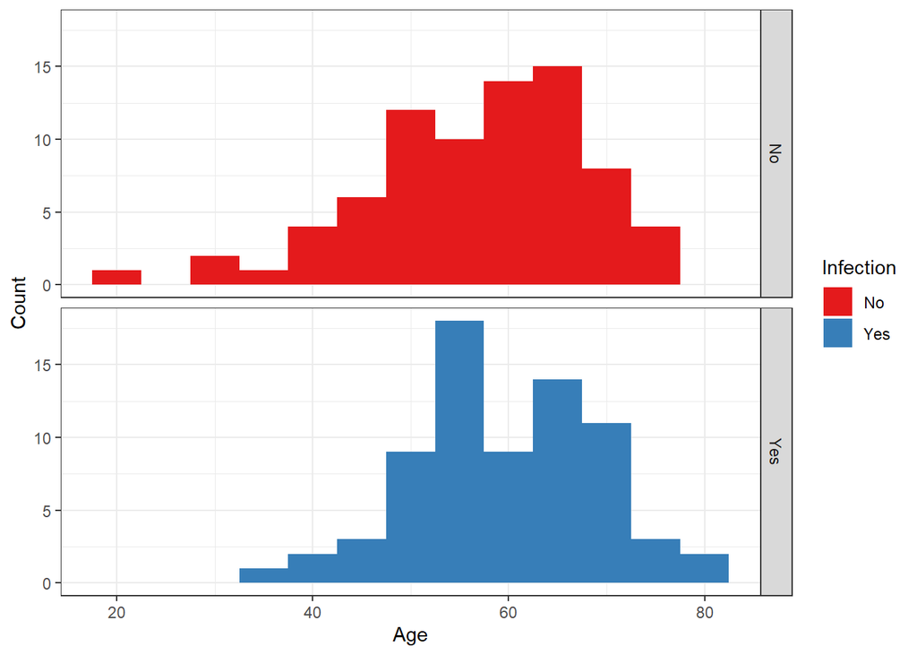

```r
ggplot(df, aes(x = age, fill = infection)) +
  geom_histogram(binwidth = 5)  +
  theme_bw() +
  scale_fill_brewer("Infection", palette = "Set1") +
  labs(x = "Age", y = 'Count') +
  facet_grid(infection ~ .)
```

## Removing the legend and adding both the variable name and levels on the facet ‘strips’

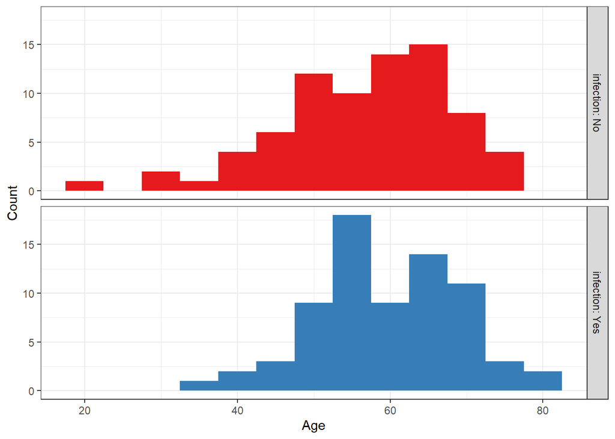

```r
ggplot(df, aes(x = age, fill = infection)) +
  geom_histogram(binwidth = 5)  +
  theme_bw() +
  scale_fill_brewer("infection", palette = "Set1") +
  labs(x = "Age", y = 'Count') +
  facet_grid(infection ~ ., labeller = label_both) +
  theme(legend.position = "none")
```

## Let’s add an extra dimension

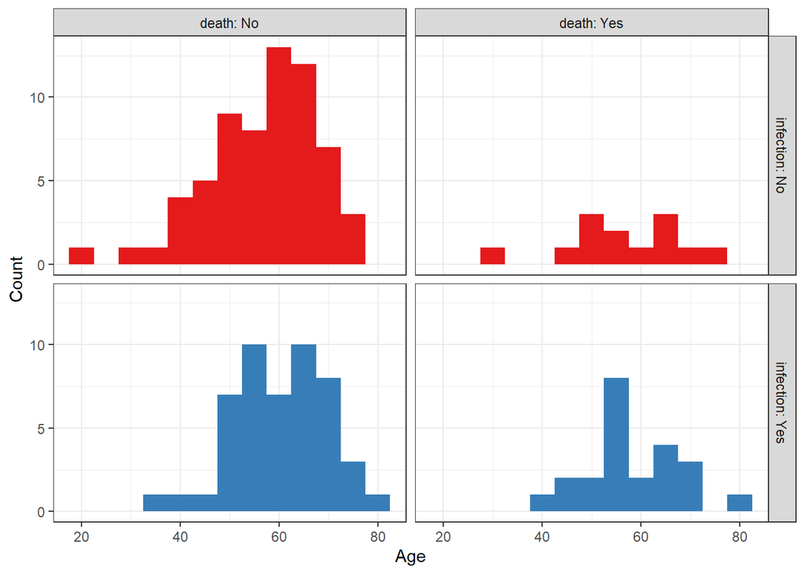

```r
ggplot(df, aes(x = age, fill = infection)) +
  geom_histogram(binwidth = 5)  +
  theme_bw() +
  scale_fill_brewer("infection", palette = "Set1") +
  labs(x = "Age", y = 'Count') +
  facet_grid(infection ~ death, labeller = label_both) +
  theme(legend.position = "none")
```

## Let’s add even more dimensions

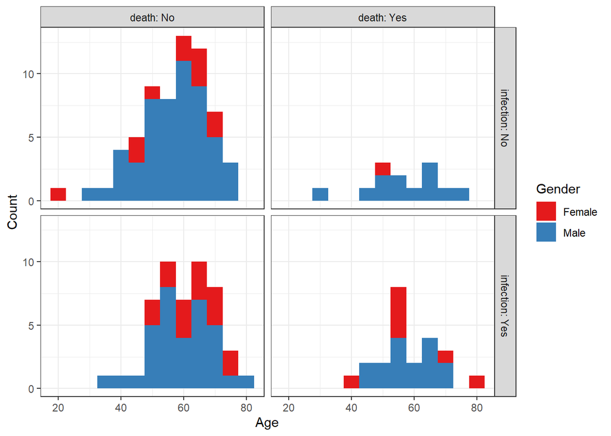

```r
ggplot(df, aes(x = age, fill = gender)) +
  geom_histogram(binwidth = 5)  +
  theme_bw() +
  scale_fill_brewer("Gender", palette = "Set1") +
  labs(x = "Age", y = 'Count') +
  facet_grid(infection ~ death, labeller = label_both)
```

## Even more dimensions

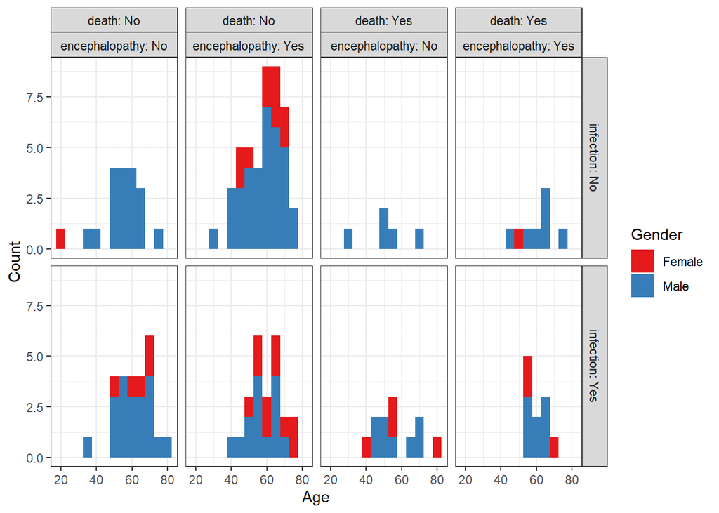

```r
ggplot(df, aes(x = age, fill = gender)) +
  geom_histogram(binwidth = 5)  +
  theme_bw() +
  scale_fill_brewer("Gender", palette = "Set1") +
  labs(x = "Age", y = 'Count') +
  facet_grid(infection ~ death + encephalopathy, labeller = label_both)
```

# Boxplots

> Create the basis of the plot by including the dataframe and mapping the age onto the y axis.

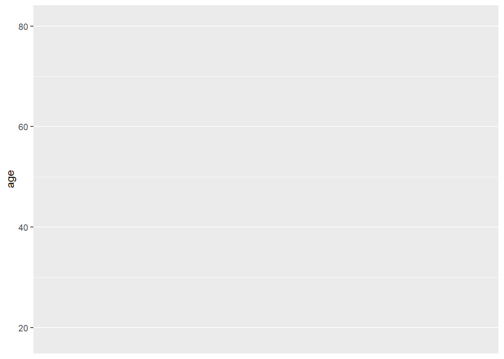

```r
ggplot(df, aes(y = age))
```

## We add `geom_boxplot()` to create the basic boxplot

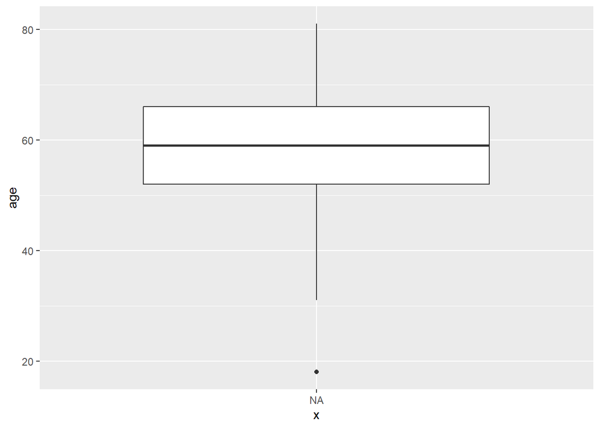

```r
ggplot(df, aes(y = age, x = NA)) +
  geom_boxplot()
```

## Adding an additional layer to overlay the boxplot

> We can add an error bar by adding `stat_boxplot()` with `geom = "errorbar"`. This gives us the traditional ’box and whisker box plot`.

> Of note, we need to add the `stat_boxplot()` function before the geom_boxplot. Remember, we are building plots layer by layer. We want the `stat_boxplot()` layer first, so we can overlay the `geom_boxpplot()` function over it the first layer. Experiment with the order of the layers to get the plot to how you want it.

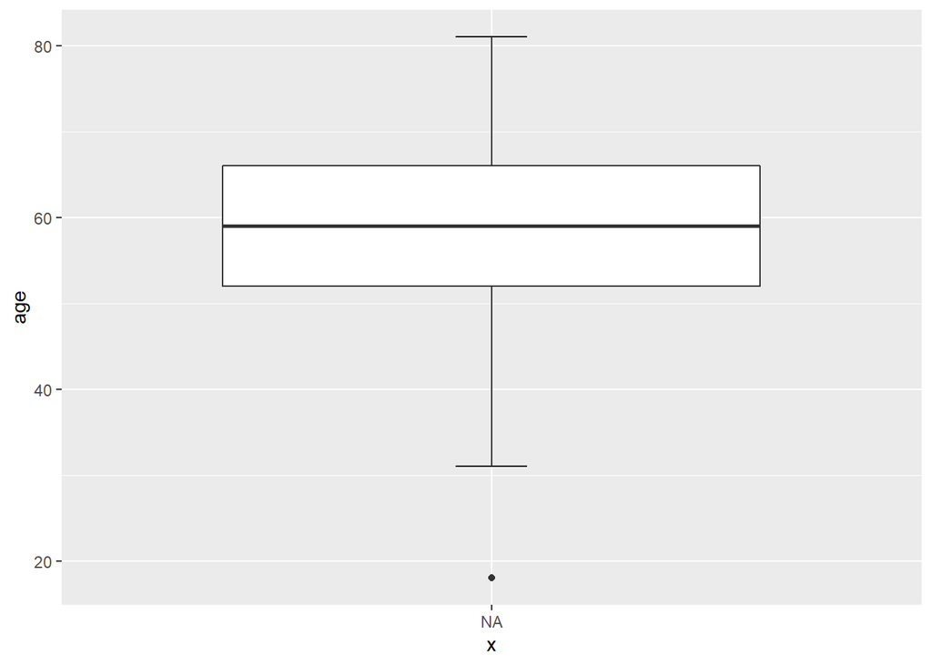

```r
ggplot(df, aes(y = age, x = NA)) +
  stat_boxplot(geom = "errorbar", width = 0.1) +
  geom_boxplot()
```

## Adding a theme

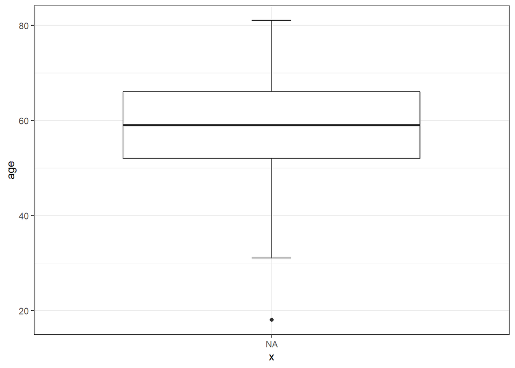

```r
ggplot(df, aes(y = age, x = NA)) +
  stat_boxplot(geom = "errorbar", width = 0.1) +
  geom_boxplot() +
  theme_bw()
```

## Remove the x axis title and text as it doesn’t make sense for a single box plot

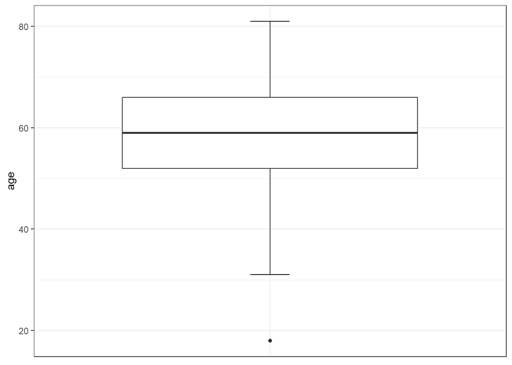

```r
ggplot(df, aes(y = age, x = NA)) +
  stat_boxplot(geom = "errorbar", width = 0.1) +
  geom_boxplot() +
  theme_bw() +
  theme(axis.title.x = element_blank(),
        axis.text.x = element_blank(),
        axis.ticks.x = element_blank())
```

## Stratified boxplots by a factor

> We can also add a fill aesthetic by infection to separate the boxplot into no infection and yes infection. To do this we will also need to map the infection variable to the x axis. I’ve also added the fill argument, so we can have separate colors for No and Yes.

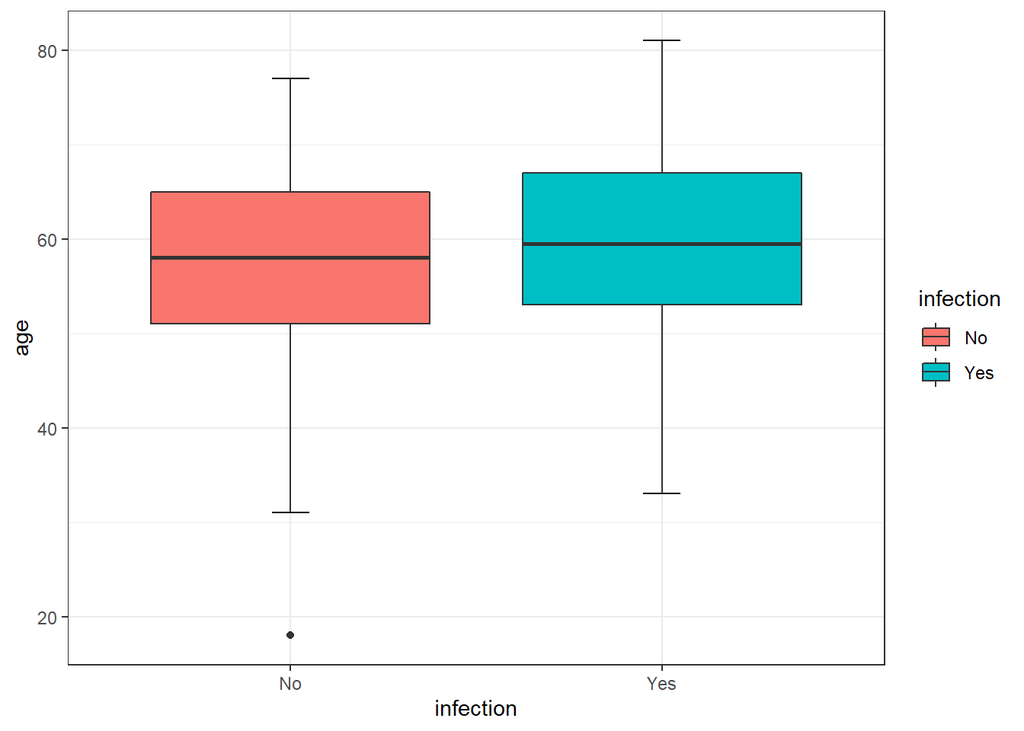

```r
ggplot(df, aes(y = age, x = infection, fill = infection)) +
  stat_boxplot(geom = "errorbar", width = 0.1) +
  geom_boxplot() +
  theme_bw()
```

> We can further clean up the plot by changing the axis title and legend title

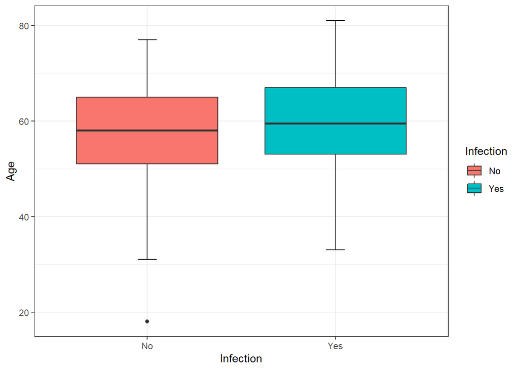

```r
ggplot(df, aes(y = age, x = infection, fill = infection)) +
  stat_boxplot(geom = "errorbar", width = 0.1) +
  geom_boxplot() +
  theme_bw() +
  scale_fill_discrete('Infection') +
  labs(x = "Infection", y = "Age")
```

## Change the colors by using a palette

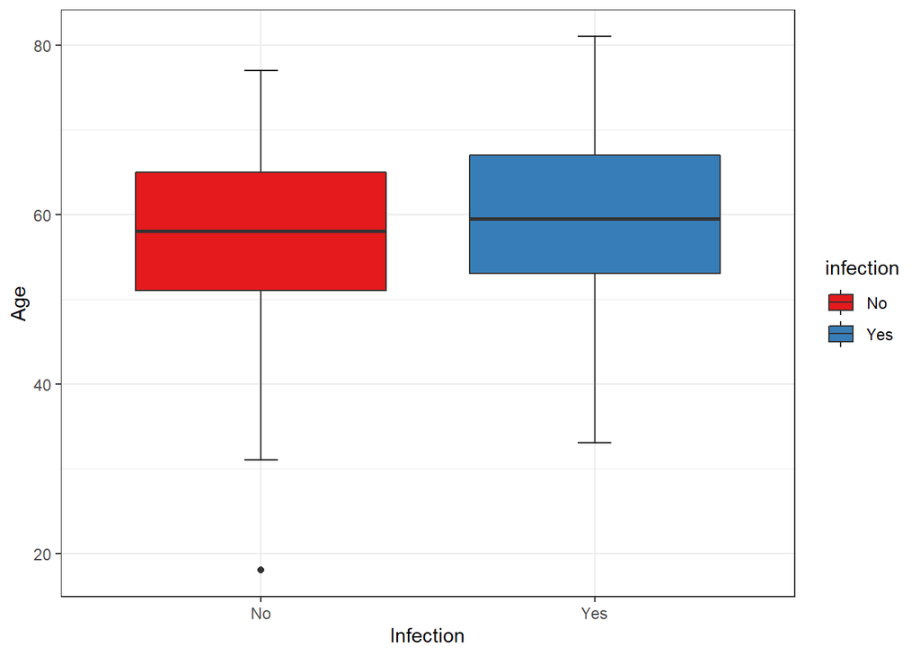

```r
ggplot(df, aes(y = age, x = infection, fill = infection)) +
  stat_boxplot(geom = "errorbar", width = 0.1) +
  geom_boxplot() +
  theme_bw() +
  scale_fill_brewer("infection", palette = "Set1") +
  labs(x = "Infection", y = "Age")
```

## Removing the legend within the `theme()` function

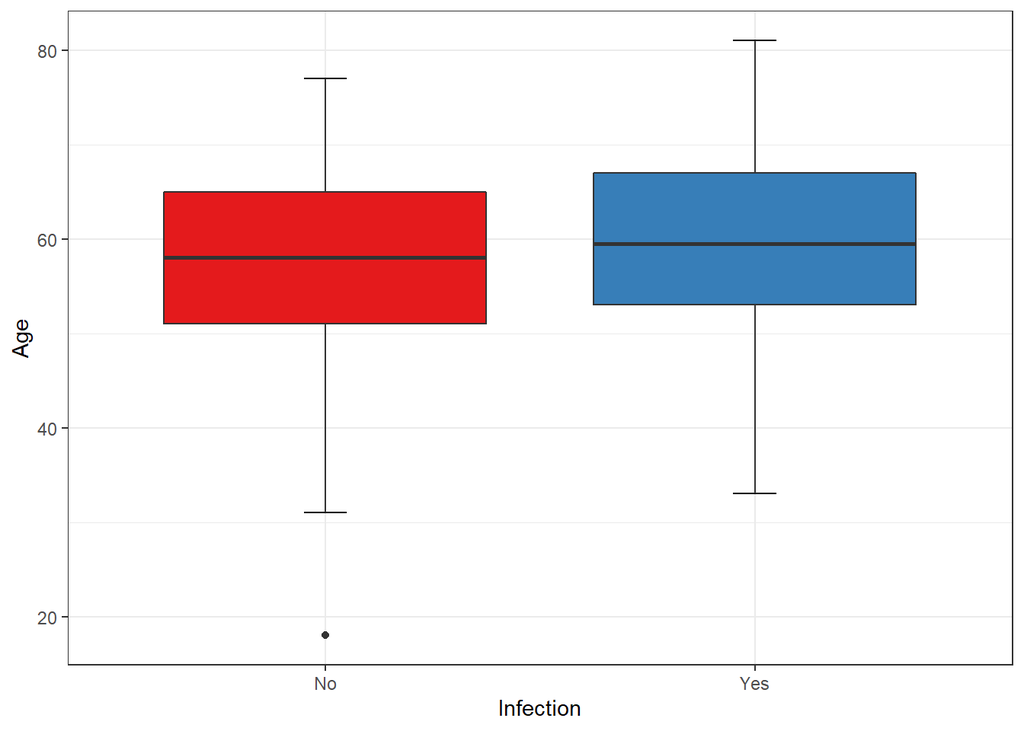

```r
ggplot(df, aes(y = age, x = infection, fill = infection)) +
  stat_boxplot(geom = "errorbar", width = 0.1) +
  geom_boxplot() +
  theme_bw() +
  scale_fill_brewer("infection", palette = "Set1") +
  labs(x = "Infection", y = "Age") +
  theme(legend.position = "none")
```

## Overlaying an additional geom (scatter)

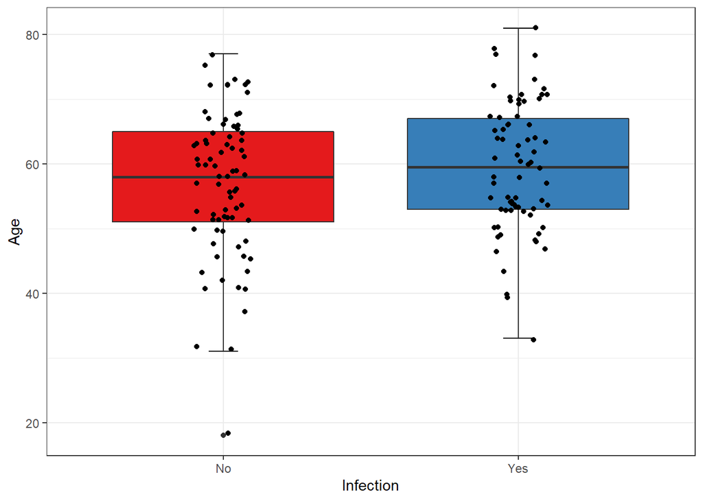

```r
ggplot(df, aes(y = age, x = infection, fill = infection)) +
  stat_boxplot(geom = "errorbar", width = 0.1) +
  geom_boxplot() +
  geom_jitter(width = .1) +
  theme_bw() +
  scale_fill_brewer("infection", palette = "Set1") +
  labs(x = "Infection", y = "Age") +
  theme(legend.position = "none")
```

> `geom_boxplot()` already shows points but only for outliers. However adding `geom_jitter()` we’re already showing the points. We can remove the duplicate outliers by adding the `outlier.shape = NA` argument within the boxplot geom

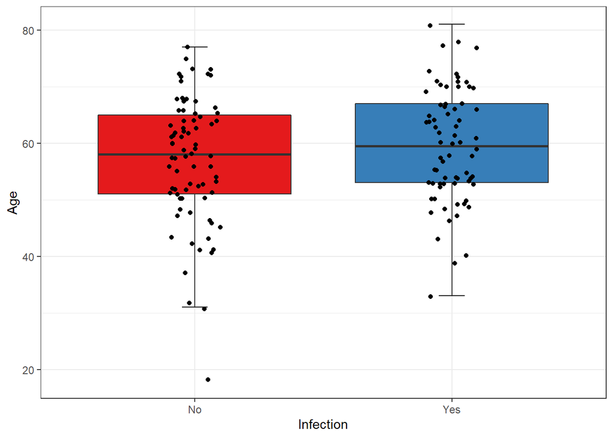

```r
ggplot(df, aes(y = age, x = infection, fill = infection)) +
  stat_boxplot(geom = "errorbar", width = 0.1) +
  geom_boxplot(outlier.shape = NA) +
  geom_jitter(width = .1) +
  theme_bw() +
  scale_fill_brewer("infection", palette = "Set1") +
  labs(x = "Infection", y = "Age") +
  theme(legend.position = "none")
```

## Mapping a color to a specific layer

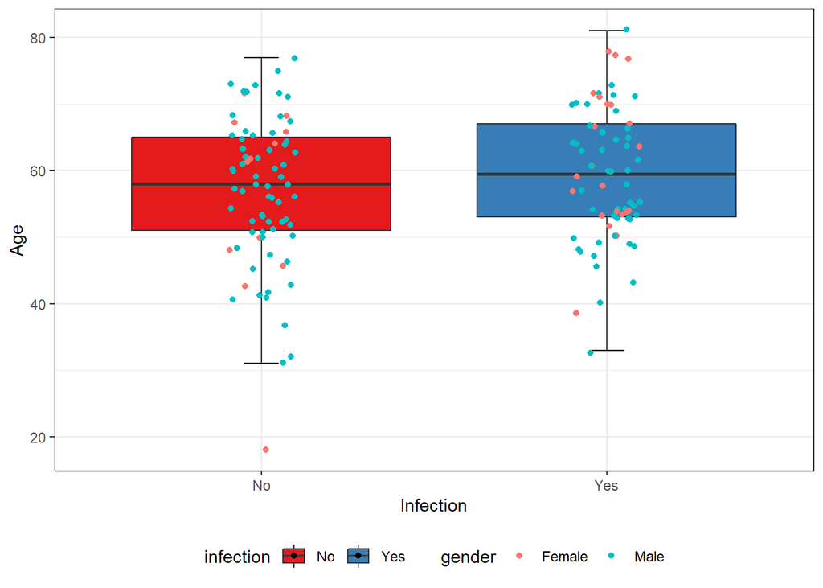

```r
ggplot(df, aes(y = age, x = infection, fill = infection)) +
  stat_boxplot(geom = "errorbar", width = 0.1) +
  geom_boxplot(outlier.shape = NA) +
  geom_jitter(width = .1, aes(color = gender)) +
  theme_bw() +
  scale_fill_brewer("infection", palette = "Set1") +
  labs(x = "Infection", y = "Age") +
  theme(legend.position = 'bottom')
```

> Now that we have gender visualized, what if we want to change the colors for the scatter layer? We can do this by using the `scale_color_brewer()`. Note ‘color’ for the ‘color’ argument and ‘fill’ for the ’fill` argument.

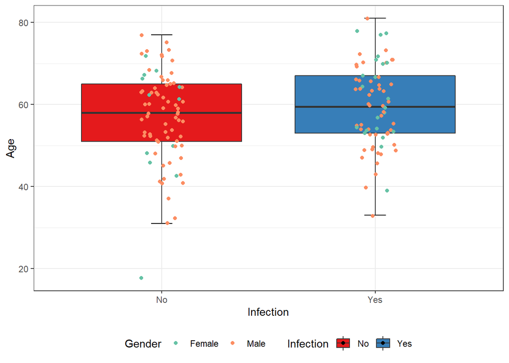

```r
ggplot(df, aes(y = age, x = infection, fill = infection)) +
  stat_boxplot(geom = "errorbar", width = 0.1) +
  geom_boxplot(outlier.shape = NA) +
  geom_jitter(width = .1, aes(color = gender)) +
  theme_bw() +
  scale_fill_brewer("Infection", palette = "Set1") +
  labs(x = "Infection", y = "Age") +
  theme(legend.position = 'bottom') +
  scale_color_brewer('Gender', palette = "Set2")
```

# Barplots

## Creating a table of statistics to plot

> We start by creating a table of the statistic we want to show, for example lets create a table of the count and percent of child stratified by infection. Recall we can pipe the dataframe `df` and group them by the two discrete (factors) child, and infection. We will then use `summarise()` along with the function `n()` to obtain its count. Next we will use the `filter()` function to remove the missing observations by specifying a logical statement `!is.na()` (the ! indicates NOT - read NOT is na), and then use `mutate()` to create a new column with the percent. We obtain the percent by dividing the `n` column by its sum of the group with the function `sum(n)`.

```r
plot_data <- df %>%
  group_by(., child, infection) %>%
  summarise(n = n()) %>%
  filter(., !is.na(child)) %>%
  group_by(., child) %>%
  mutate(., percent = n / sum(n))
plot_data
```

```
# A tibble: 6 × 4
# Groups:   child [3]
  child infection     n percent
  <fct> <fct>     <int>   <dbl>
1 A     No            4   0.8
2 A     Yes           1   0.2
3 B     No           33   0.471
4 B     Yes          37   0.529
5 C     No           38   0.567
6 C     Yes          29   0.433
```

## Maping the dataframe into ggplot and adding the `geom_col()` statistics

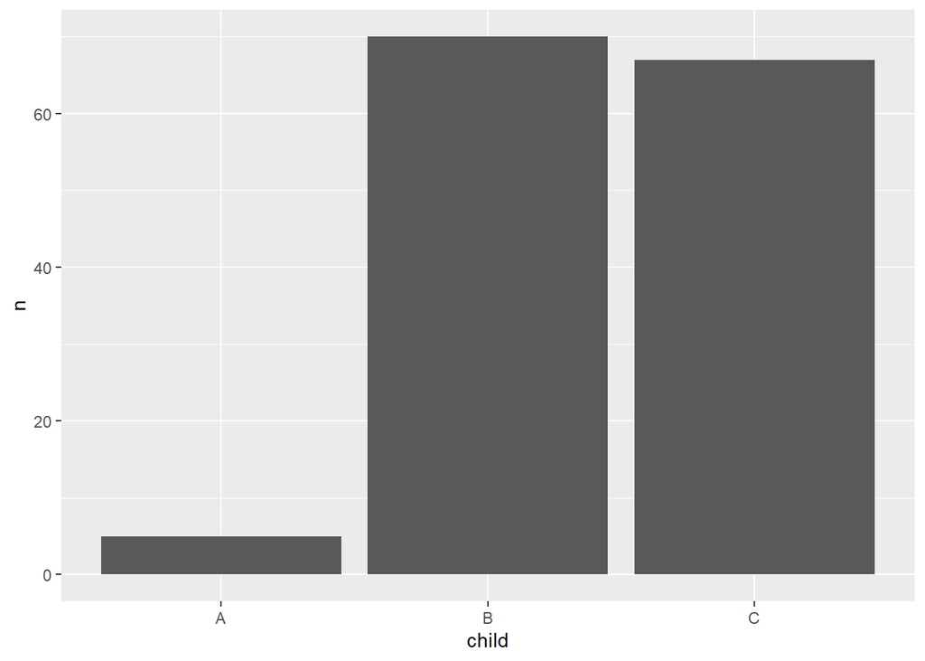

```r
ggplot(plot_data, aes(x = child, y = n)) +
  geom_col()
```

## Adding a theme

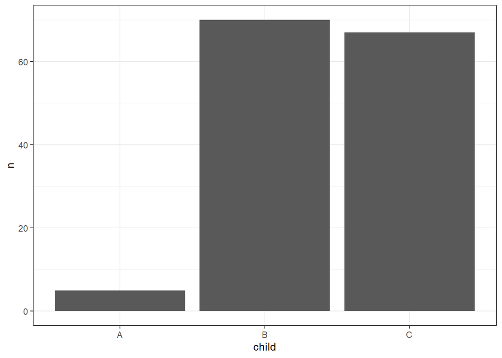

```r
ggplot(plot_data, aes(x = child, y = n)) +
  geom_col() +
  theme_bw()
```

## Changing the labels

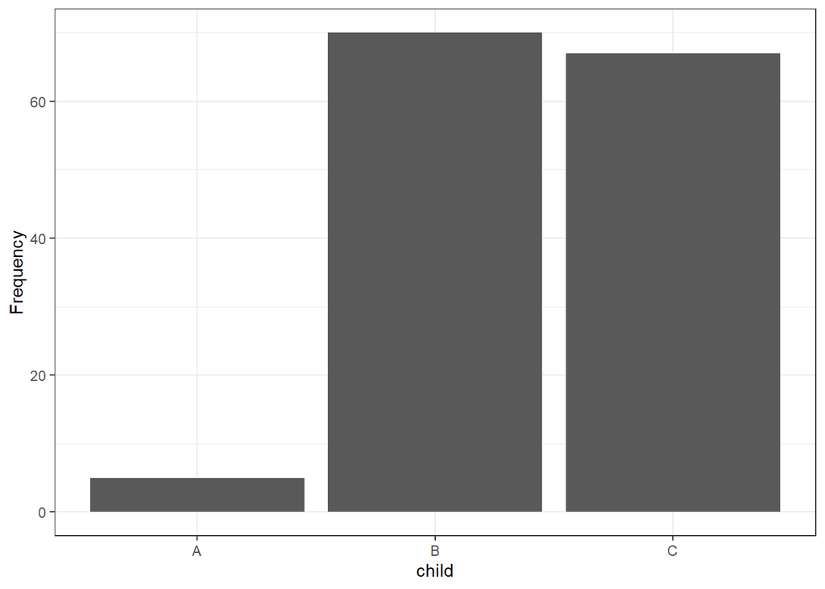

```r
ggplot(plot_data, aes(x = child, y = n)) +
  geom_col() +
  theme_bw() +
  labs(y = "Frequency")
```

## Stratifying with a color

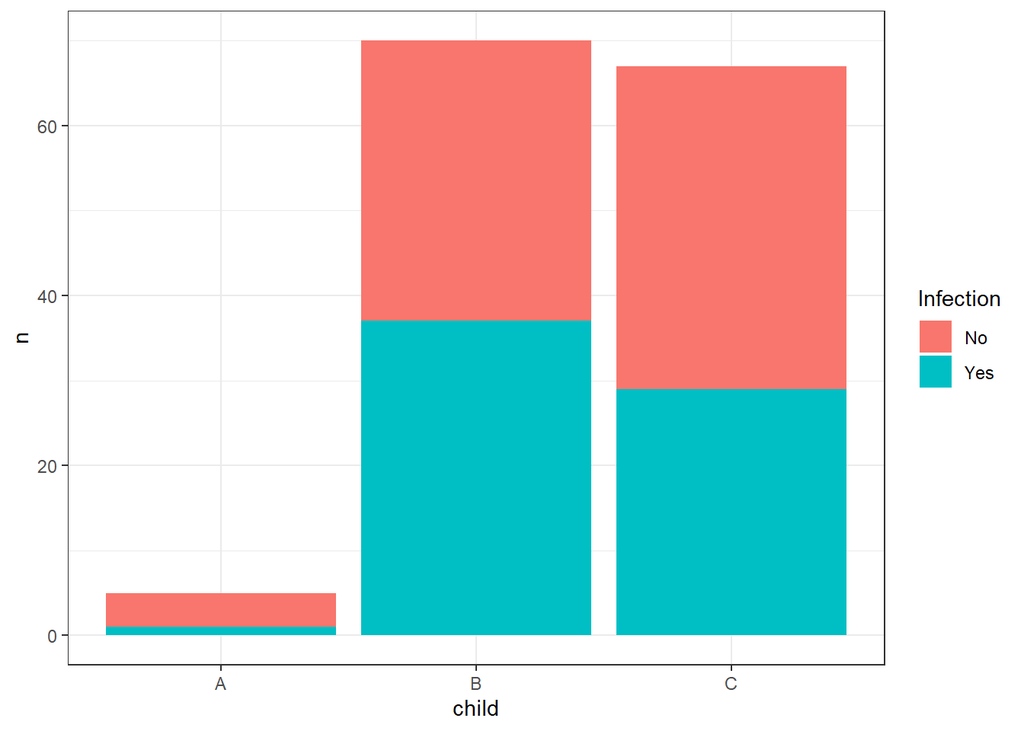

```r
ggplot(plot_data, aes(x = child, y = n, fill = infection)) +
  geom_col() +
  theme_bw() +
  scale_fill_discrete('Infection')
```

## Changing the position of the barplot

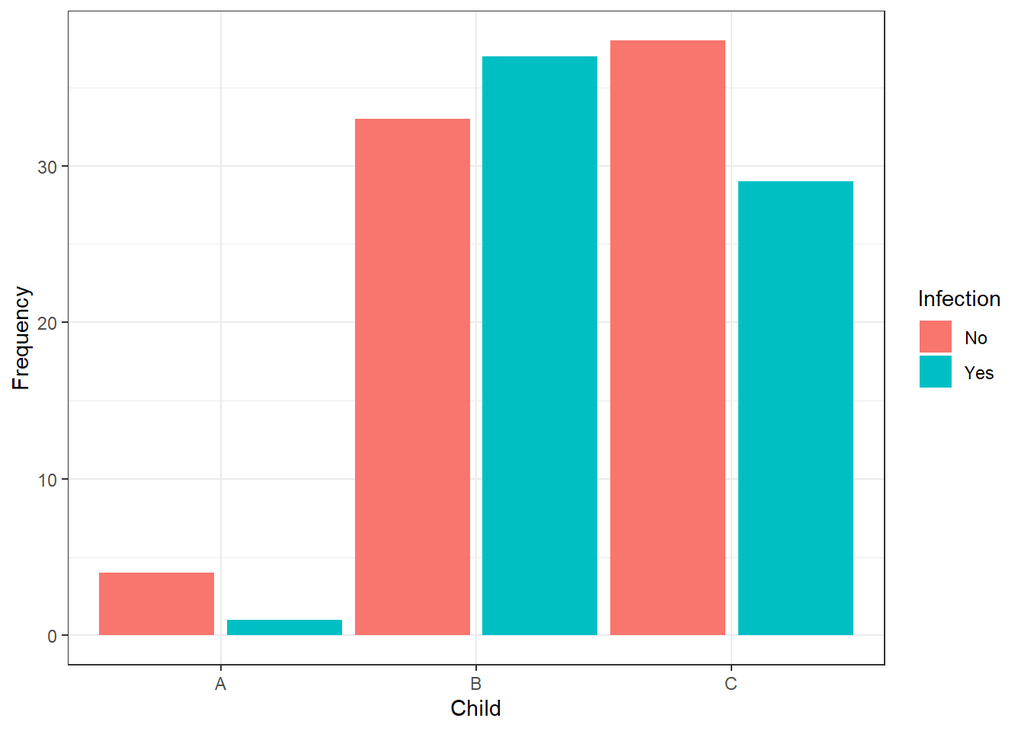

```r
ggplot(plot_data, aes(x = child, y = n, fill = infection)) +
  theme_bw() +
  geom_col(position = position_dodge(width = 1)) +
  labs(y = "Frequency", x = 'Child') +
  scale_fill_discrete('Infection')
```

## Changing the color pallete

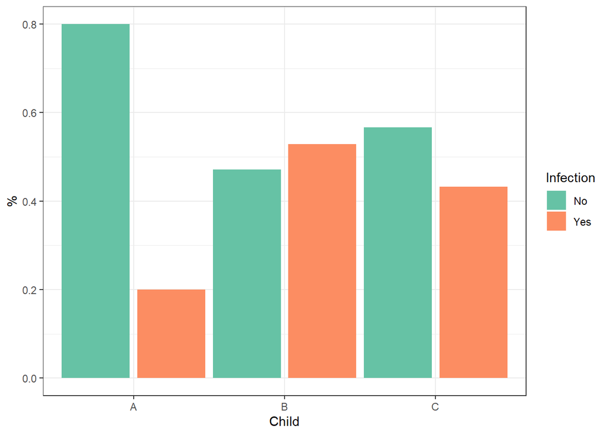

```r
ggplot(plot_data, aes(x = child, y = percent, fill = infection)) +
  theme_bw() +
  geom_col(position = position_dodge(width = 1)) +
  labs(y = "%", x = 'Child') +
  scale_fill_brewer('Infection', palette = 'Set2')
```

## Making the scales into percents

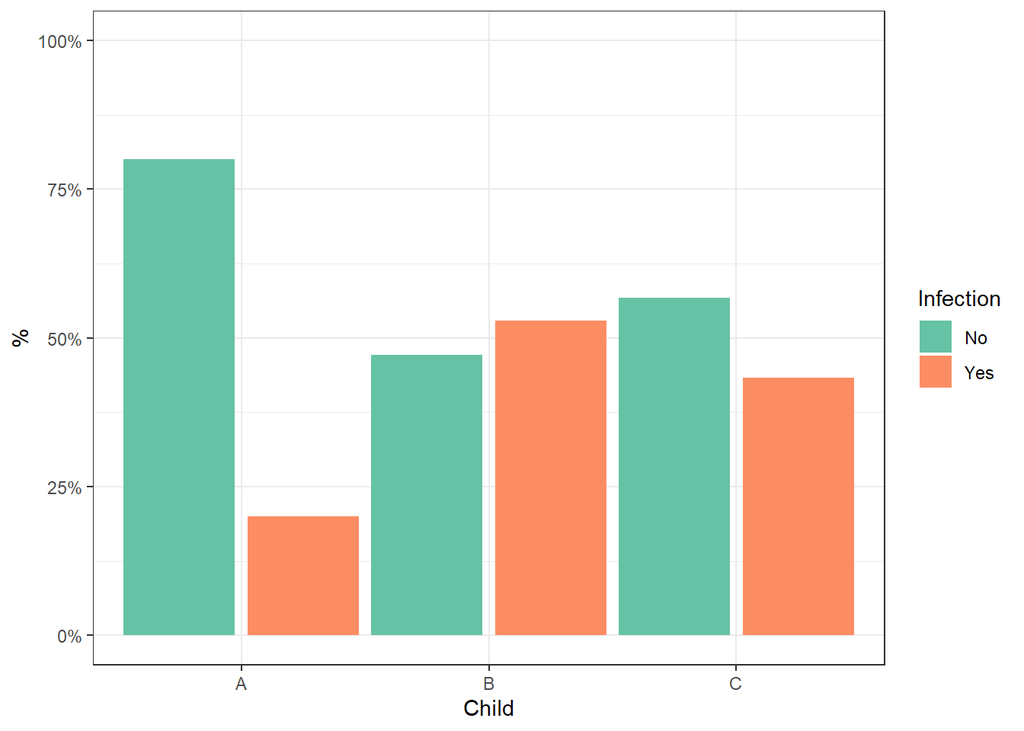

```r
ggplot(plot_data, aes(x = child, y = percent, fill = infection)) +
  theme_bw() +
  geom_col(position = position_dodge(width = 1)) +
  labs(y = "%", x = 'Child') +
  scale_fill_brewer('Infection', palette = 'Set2') +
  scale_y_continuous(labels = scales::percent_format(), limits = c(0, 1))
```

## Adding a text overlay of the percent

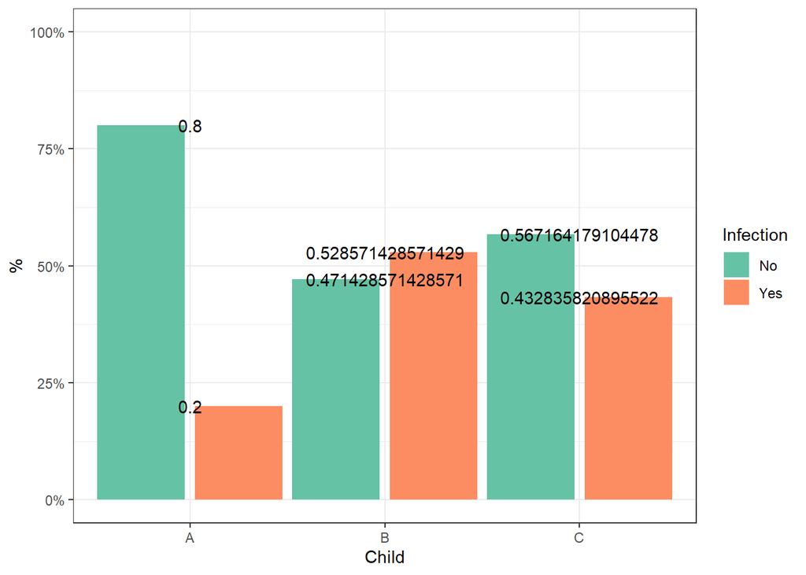

```r
ggplot(plot_data, aes(x = child, y = percent, fill = infection)) +
  theme_bw() +
  geom_col(position = position_dodge(width = 1)) +
  labs(y = "%", x = 'Child') +
  scale_fill_brewer('Infection', palette = 'Set2') +
  scale_y_continuous(labels = scales::percent_format(), limits = c(0, 1)) +
  geom_text(aes(y = percent, label = percent))
```

### Cleaning up the text

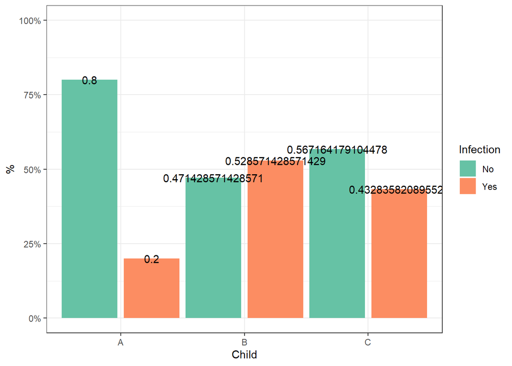

```r
ggplot(plot_data, aes(x = child, y = percent, fill = infection)) +
  theme_bw() +
  geom_col(position = position_dodge(width = 1)) +
  labs(y = "%", x = 'Child') +
  scale_fill_brewer('Infection', palette = 'Set2') +
  scale_y_continuous(labels = scales::percent_format(), limits = c(0, 1)) +
  geom_text(aes(y = percent, label = percent), position = position_dodge(width = 1))
```

## Rounding the percent and adding a percent symbol

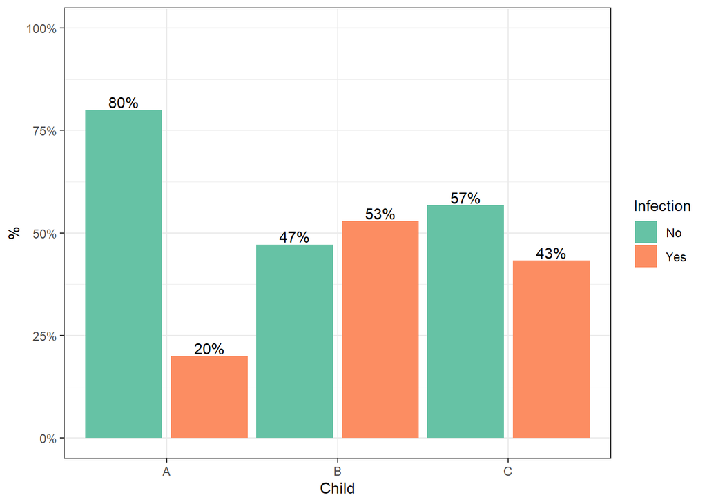

```r
ggplot(plot_data, aes(x = child, y = percent, fill = infection)) +
  theme_bw() +
  geom_col(position = position_dodge(width = 1)) +
  labs(y = "%", x = 'Child') +
  scale_fill_brewer('Infection', palette = 'Set2') +
  scale_y_continuous(labels = scales::percent_format(), limits = c(0, 1)) +
  geom_text(aes(y = percent + .02, label = paste0(round(percent*100, 0), '%')), position = position_dodge(width = 1))
```

## Adding the count as a label

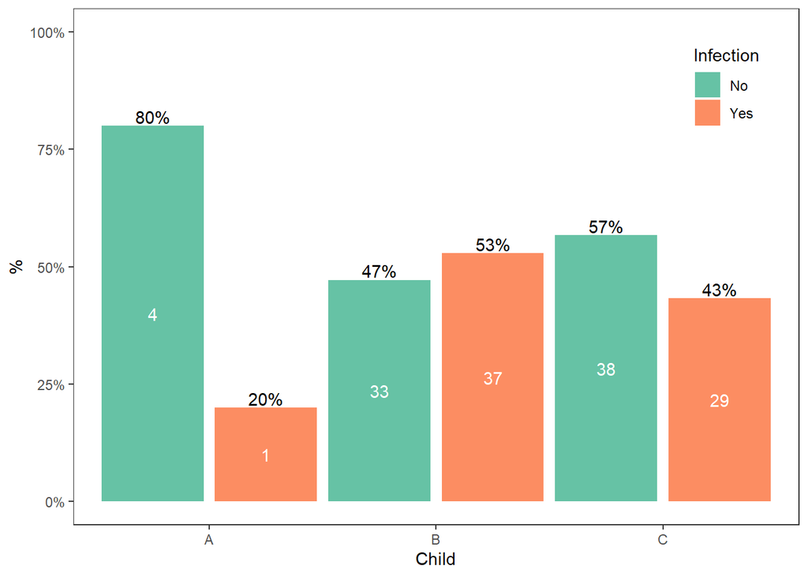

```r
ggplot(plot_data, aes(x = child, y = percent, fill = infection)) +
  theme_bw() +
  geom_col(position = position_dodge(width = 1)) +
  labs(y = "%", x = 'Child') +
  scale_fill_brewer('Infection', palette = 'Set2') +
  scale_y_continuous(labels = scales::percent_format(), limits = c(0, 1)) +
  geom_text(aes(y = percent + .02, label = paste0(round(percent*100, 0), '%')), position = position_dodge(width = 1)) +
  geom_text(aes(y = percent/2, label = n), position = position_dodge(width = 1), color = 'white') +
  theme(legend.position = c(.9, .85),
        panel.grid = element_blank())
```

## How NOT to use Barplots

> This is an example of an improper use of barplots commonly found in many publications. The barplots illustrates the mean age stratified by infection. The errorbar represents the sd of the mean.

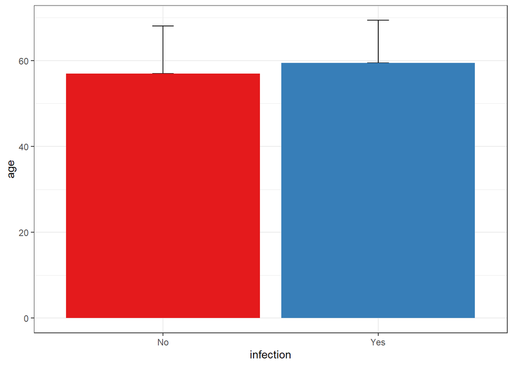

```r
plot_data <- df %>%
  group_by(., infection) %>%
  summarise(., mean = mean(age), sd = sd(age))

ggplot(plot_data, aes(x = infection, y = mean, fill = infection)) +
  geom_errorbar(aes(ymin = mean, ymax = mean + sd), width = .1) +
  geom_bar(position = position_dodge(), stat = "identity") +
  scale_fill_brewer("infection", palette = "Set1") +
  theme_bw() + labs(x = "infection", y = "age") +
  theme(legend.position = "none")
```

# Arranging Plots together

> Now that we have constructed the multitude of plots, we would commonly want to present certain plots together to illustrate a certain point in our manuscript. We start by saving each plot we would like to present together as an object in R using the `<-` to assign the plot to an object name.

```r
plot_data <- df %>%
  group_by(., child, infection) %>%
  summarise(n = n()) %>%
  na.omit() %>%
  group_by(., child) %>%
  mutate(., percent = n / sum(n))
p1 <- ggplot(plot_data, aes(x = child, y = percent, fill = infection)) +
  theme_bw() +
  geom_bar(stat = 'identity', position = position_dodge2()) +
  labs(y = "%", x = 'Child') +
  scale_fill_brewer('Infection', palette = 'Set1') +
  scale_y_continuous(labels = scales::percent_format(), limits = c(0, 1)) +
  geom_text(aes(y = percent, label = paste0(round(percent*100, 0), '%')), position = position_dodge2(.9), vjust = -.5) +
  geom_text(aes(y = percent/2, label = n), position = position_dodge2(.9), color = 'white') +
  theme(legend.position = c(.9, .85),
        panel.grid = element_blank())

p2 <- ggplot(df, aes(y = age, x = infection, fill = infection)) +
  stat_boxplot(geom = "errorbar", width = 0.1) +
  geom_boxplot(outlier.shape = NA) +
  geom_jitter(width = .1, aes(color = gender)) +
  theme_bw() +
  scale_fill_brewer("Infection", palette = "Set1", guide = F) +
  scale_color_discrete('Gender') +
  labs(x = "Infection", y = "Age") +
  theme(legend.position = c(.85, .15), panel.grid = element_blank())

p3 <- ggplot(df, aes(x = age, fill = infection)) +
  geom_histogram(binwidth = 5)  +
  theme_bw() +
  scale_fill_brewer("infection", palette = "Set1") +
  labs(x = "Age", y = 'Count') +
  facet_grid(infection ~ death, labeller = label_both) +
  theme(legend.position = "none", panel.grid = element_blank())

p4 <- ggplot(df, aes(y = age, x = infection, fill = infection)) +
  geom_dotplot(binaxis = "y", stackdir = "center",
               binwidth = 1, method = "histodot") +
  stat_summary(fun.y = median, fun.ymin = median, fun.ymax = median, geom = "crossbar", width = 0.3) +
  theme_bw() +
  theme(legend.position = "none",
        panel.grid = element_blank()) +
  scale_fill_brewer("Infection", palette = "Set1") +
  labs(y = "Age", x = "Infection") +
  scale_y_continuous(breaks = seq(0,100, 10))
```

> Now that we have saved the plots as R objects, we can view the plots by simply running the object names.

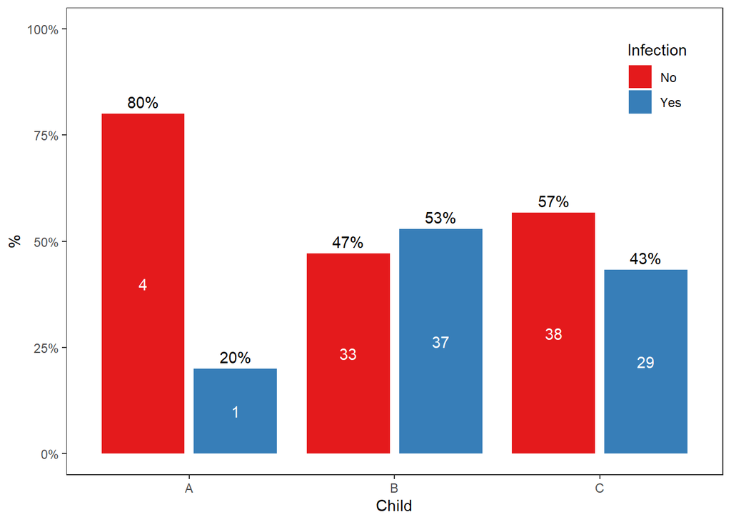

```r
p1
```

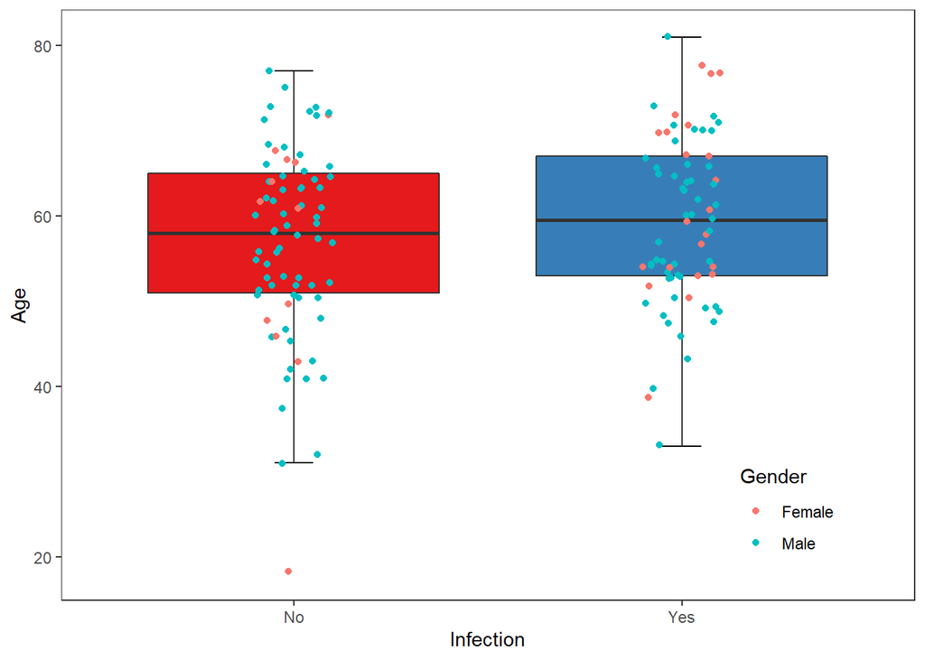

```r
p2
```

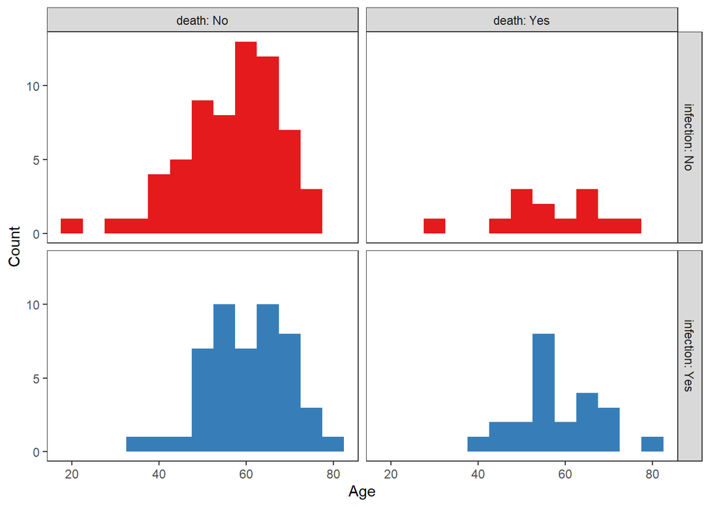

```r
p3
```

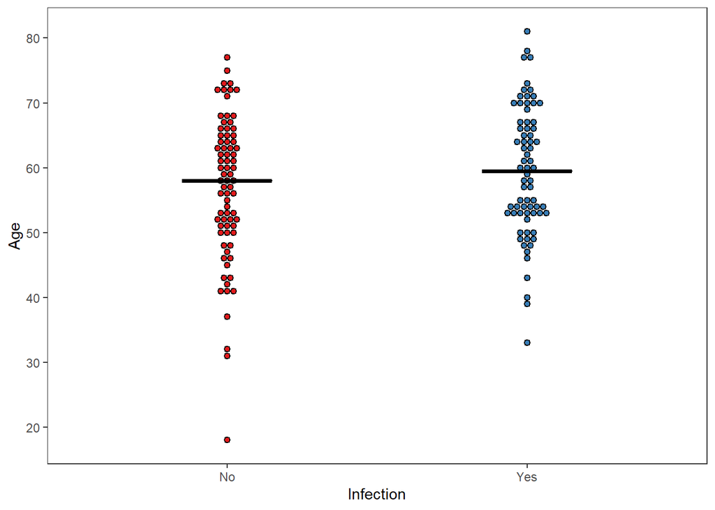

```r
p4
```

> To arrange the plots together, we can utilize a helpful function from the package `patchwork`. If you don’t have `patchwork` installed, please install it using `install.packages('patchwork')` and loading the package with `library(patchwork)`. The syntax for arranging plots is performed by using the `|` bar syntax and the `/` forward slash syntax. The `|` allows us to arrange the plots left and right, and the `/` allows us to arrange the plots above and below.

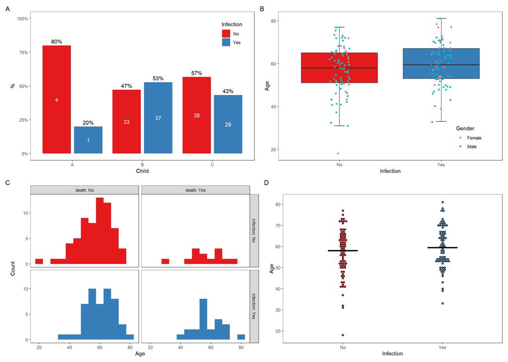

```r
# library(patchwork)
# install.packages('patchwork')

pg <- (p1 | p2) / (p3 | p4) +
  plot_annotation(tag_levels = 'A')

pg
```

> If you would like to save your ‘merged’ plot grid, then you will need to save this new grid into a object. In this example, the plot is saved into an object called `pg`. We would then save this plot using the `ggsave()` function.

```
ggsave('merged_plot.png', pg, height = 10, width = 14)
```

# References/Resources

[R for Data Science](http://r4ds.had.co.nz/)

[Tidyverse Homepage](https://www.tidyverse.org/)

[ggplot2 Cheatsheet](https://github.com/rstudio/cheatsheets/raw/master/data-visualization-2.1.pdf)

[R Studio Cheatsheets](https://www.rstudio.com/resources/cheatsheets/)